# Manage permissions in HCP Terraform

As your Terraform usage grows, you may need to control which resources HCP Terraform users can access. In this tutorial, you will create a team, assign it permissions for a workspace, and invite users to the team.

An organization owner can assign teams either fixed permission sets or custom permissions at the workspace or project level. We recommend following the principle of least privilege when possible and only giving teams access to the resources they need for their job function.

Note

Teams are available in HCP Terraform **Essentials** Edition. Refer to [HCP Terraform pricing](https://www.hashicorp.com/products/terraform/pricing) for details.

## Prerequisites

For this tutorial, you will need:

- An HCP Terraform account.
- Organization owner permissions for a Essentials edition HCP Terraform organization.

## Create a new team

The **owners** team is the default team of an HCP Terraform organization. This team has [every available permission in the organization](https://developer.hashicorp.com/terraform/cloud-docs/users-teams-organizations/permissions#organization-owners), so it is important to create restricted team access before adding new members.

To add a new team, navigate to your organization **Settings** > **Teams**. Click **Create a team**.

[figure not shown]

Enter the name `Dev-Team`, then click **Create**.

The team settings page lets you configure broad organization-level permissions.

[figure not shown]

Leave these permissions blank. In the next section, you will assign workspace-level permissions, which grant more targeted access than organization-level permissions.

## Assign workspace permissions

Navigate to the **Workspaces** page and create a new CLI-driven workspace named `dev-webapp` in your organization's `Default` project.

Then, go to the `dev-webapp` workspace's **Settings** > **Team Access** page.

Click **Add team and permissions**.

[figure not shown]

Fixed permission sets let you easily set predefined collections of privileges for common job functions. You can also set custom permissions if you need to define more granular scope.

In the **Team** dropdown, select the **Dev-Team**. Then, select the **Write** permissions set. On the righthand side, the workspace displays the permissions in this fixed permission set. Click **Assign permissions**.

[figure not shown]

The **Dev-Team** now has **Write** permissions to this workspace, but the team does not yet have any members.

## Invite a user to your organization and team

To collaborate with your team members in HCP Terraform, you need to grant them access to the same HCP Terraform organization. You can add users to an organization by inviting them using their email address. Even if your team member has not signed up for HCP Terraform yet, they can still accept the invitation and create a new account.

Navigate to your **Organization Settings** > **Users**, then click **Invite a user**.

[figure not shown]

Enter the email address of the teammate you need to add and select **Dev-Team** from the **Add to teams** dropdown. Then, click **Invite user**.

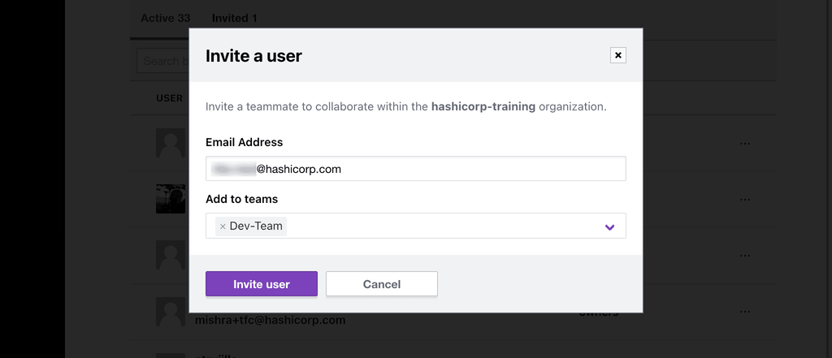

HCP Terraform will send the user an email invite that they must accept to join your organization. If the user does not yet have an account, HCP Terraform will prompt them to create one and automatically add them to your organization and team.

## Review team membership

Once your teammates accept their invitations, navigate to **Organization Settings** > **Teams** and select your **Dev-Team**. The **Members** section now lists the new team member.

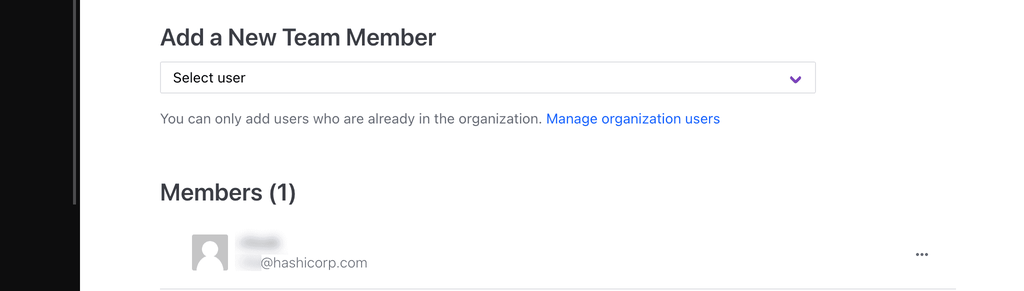

You can manage team membership for users already in your organization from this page.

## Next steps

In this tutorial, you created a new team in your organization, assigned the team workspace-specific privileges, and invited a new user to your HCP Terraform organization and team. You also reviewed how to add existing organization users to teams.

Review the following resources to learn more about managing permissions and enabling your team in HCP Terraform:

- Learn how to assign project-specific permissions to teams.
- Review the interaction of workspace, project, and organization-wide [permissions in HCP Terraform](https://developer.hashicorp.com/terraform/cloud-docs/users-teams-organizations/permissions).
- Learn how to enable no-code Terraform provisioning for self-service workflows.
- Learn how to use short-lived dynamic provider credentials.